# Activity Level Data Analysis

## Activity Level Data Analysis

This report looks at some of the trends from a fitness band that tracked activity on an individual from October 1, 2012 to Novmber 30, 2012. The data consists of the number of steps taken in a 5 minute interval, the date, and the interval during the day.

The first step is to read in the dataset as `raw`.

```r
raw <- read.csv("activity.csv", sep = ",")
raw$date <- as.POSIXct(raw$date, format = "%Y-%m-%d")   # Convert date to POSIXct object

# Convert 5-min intervals into times (Group_by needs POSIXct, not POSIXlt)
raw$time <- as.POSIXct(strptime(sprintf('%04d', raw$interval), format='%H%M'))
```

## Daily Totals

What is the mean total number of steps taken per day? To do this, we sum the total number of steps taken per day `total_per_day` and create a histogram showing the distribution of daily total steps. We then calculate the median and mean of this distribution.

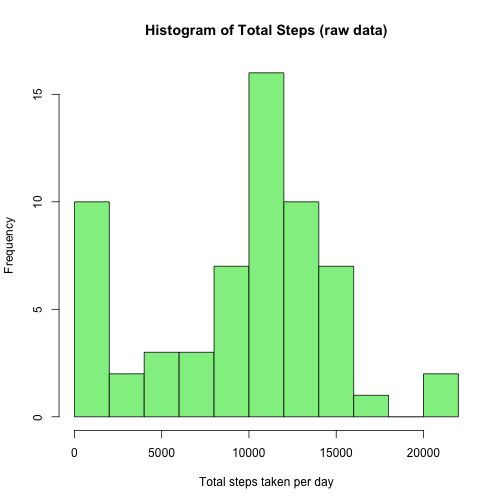

```r
# Sum the total steps per days, grouping by date
library(dplyr)
total_per_day <- raw %>% group_by(date) %>% summarize(total = sum(steps, na.rm = T))

# Plot a histogram of total steps per day, ignore NA values
hist(total_per_day$total, 15,
     xlab = "Total steps taken per day",
     main = "Histogram of Total Steps (raw data)",
     col = "lightgreen")
```

### Median of raw data

```r
# Calculate the median daily total
median(total_per_day$total)
```

```
## [1] 10395
```

### Mean of raw data

```r
# Calculate the mean daily total
mean(total_per_day$total)
```

```
## [1] 9354.23
```

## Daily Activity Levels

What is the average daily activty level?

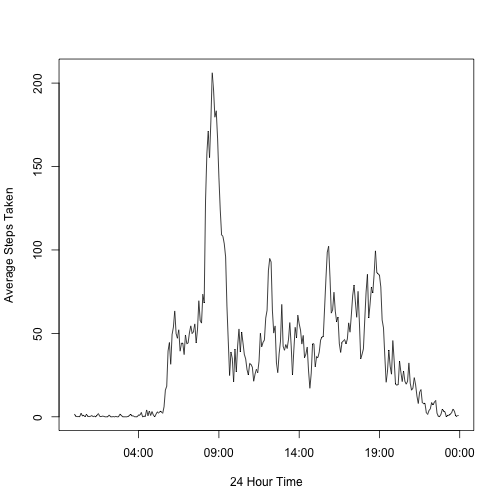

```r
# Average daily acitivty, grouping by the daily 5-min time interval
avgDaily <- raw %>% group_by(time) %>% summarize(average = mean(steps, na.rm = T))
plot(avgDaily$time,
     avgDaily$average,
     type = "l",
     xlab = "24 Hour Time",
     ylab = "Average Steps Taken")
```

```r
# Calculate in which 5-min time interval the maximum average activity level occurs
maxInt <- strftime(avgDaily$time[which.max(avgDaily$average)], format = "%H:%M")
```

### Maximum 5-min interval

The maximum average 5-min interval occurs at **08:35**. This can be attributed to the morning rush hour commute.

## Creating Tidy Data

The total number of `NA` values in the raw data is **2304** and is found via `sum(is.na(raw$steps))`.

Using the mean step values from the different 5-min time intervals, we replace the `NA` values so that we have a tidy dataset (`tidy`) where each row is a complete observation. This is done using the following code.

```r
# Replace NA values with mean values from equivalent intervals on other days
tidy <- raw
for (i in 1:length(tidy$steps)) {
        if (is.na(tidy$steps[i])) {
                int <- tidy$time[i]
                tidy$steps[i] <- avgDaily$average[avgDaily$time == int]
        }
}
```

Using the `tidy` dataset, we now plot a histogram of total daily activity and find the new median and mean.

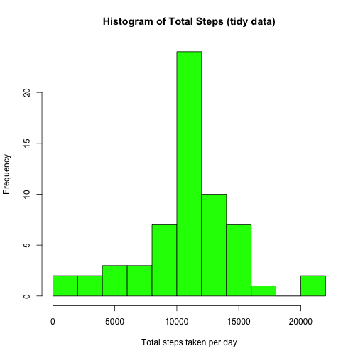

```r
# Plot histogram of tidy data
total_per_day_tidy <- tidy %>% group_by(date) %>% summarize(total = sum(steps))
hist(total_per_day_tidy$total, 15,
     xlab = "Total steps taken per day",
     main = "Histogram of Total Steps (tidy data)",
     col = "green")
```

### Median of tidy data

```r
# Calculate the median daily total
median(total_per_day_tidy$total)
```

```
## [1] 10766.19
```

### Mean of tidy data

```r
# Calculate the mean daily total
mean(total_per_day_tidy$total)
```

```
## [1] 10766.19
```

The median and mean of the `tidy` dataset are both larger than those of the `raw` dataset. This is due to additional mean values that were added to the tidy dataset.

## Weekends vs. Weekdays

To determine what differences, if any, are present in activity levels taken on the weekend vs. a weekday, first we label each date with the type of day it is. We then group the `tidy` data by `time, day` and take the mean of the resultant, grouped, dataset.

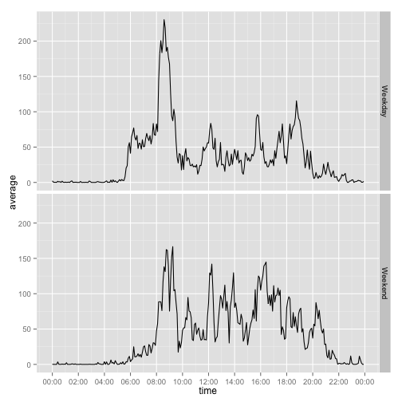

```r
library(ggplot2)
library(scales)
days <- weekdays(tidy$date)

for (i in 1:length(days)) {
        if (days[i] == "Saturday" | days[i] == "Sunday") {
                tidy$day[i] = "Weekend"
        } else  tidy$day[i] = "Weekday"
}

avgDayType <- tidy %>% group_by(time, day) %>% summarize(average = mean(steps, na.rm = T))

# Create a panel plot of average daily activity for weekdays and weekends
g <- ggplot(avgDayType, aes(time, average))
p <- g + geom_line() + facet_grid(day ~ .) +
        scale_x_datetime(breaks = date_breaks("2 hour"),  labels = date_format("%H:%M", tz = "America/Los_Angeles"))
print(p)
```